# PEC2

Erika Martínez

5 de mayo, 2023

# 1. Estadística descriptiva

En primer lugar, realizamos un análisis descriptivo de algunas variables y de sus valores comparativos entre regiones. Realizaremos un gráfico que compare los valores medios de los factores que pueden influir en la felicidad. Concretamente, queremos visualizar un gráfico que compare la media entre las regiones de las variables GpC, LE, Freedom, Family, GC y Generosity. El gráfico debe mostrar el valor medio de cada variable en cada región. Cada región se representa en un color distinto. Escoged el gráfico o gráficos que mejor visualice(n) esta comparación entre regiones.

Para realizar este apartado podéis usar la función ggplot de la librería gráfica ggplot2. Para realizar el cálculo de la media de las variables en cada región, podéis usar group_by y summarise de la librería dplyr.

Interpretad el gráfico o gráficos brevemente.

## 1.1. Cargar las librerías y el archivo de datos

```r
# Cargar el paquete ggplot2
library(ggplot2)

# Cargamos el paquete dplyr
library(dplyr)

# Cargamos el paquete tidyr
library(tidyr)

#Cargamos el paquete knitr para hacer tablas
library(knitr)
```

Cargamos el archivo .csv

```r
#Leer el fichero Happiness-clean.csv
happiness <- read.csv("Happiness-clean.csv")

#Observar los primeros valores del dataframe happiness.
head(happiness)
```

```
##       Country         Region HR    HS   LCI   UCI     GpC  Family      LE
## 1     Denmark Western Europe  1 7.526 7.460 7.592 1.44178 1.16374 0.79504
## 2 Switzerland Western Europe  2 7.509 7.428 7.590 1.52733 1.14524 0.86303
## 3     Iceland Western Europe  3 7.501 7.333 7.669 1.42666 1.09610 0.86733
## 4      Norway Western Europe  4 7.498 7.421 7.575 1.57744 1.12690 0.79579
## 5     Finland Western Europe  5 7.413 7.351 7.475 1.40598 1.13464 0.81091
## 6      Canada  North America  6 7.404 7.335 7.473 1.44015 1.09610 0.82760
##   Freedom      GC Generosity
## 1 0.57941 0.44453    0.36171
## 2 0.58557 0.41203    0.28083
## 3 0.56624 0.14975    0.47678
## 4 0.59609 0.35776    0.37895
## 5 0.57104 0.41004    0.25492
## 6 0.57370 0.31329    0.44834
```

## 1.2. Examinar el tipo de datos

```r
#Observar la estructura del fichero "happiness-clean".
str(happiness)
```

```
## 'data.frame':    157 obs. of  12 variables:
##  $ Country   : chr  "Denmark" "Switzerland" "Iceland" "Norway" ...
##  $ Region    : chr  "Western Europe" "Western Europe" "Western Europe" "Western Europe" ...
##  $ HR        : int  1 2 3 4 5 6 7 8 9 10 ...
##  $ HS        : num  7.53 7.51 7.5 7.5 7.41 ...
##  $ LCI       : num  7.46 7.43 7.33 7.42 7.35 ...
##  $ UCI       : num  7.59 7.59 7.67 7.58 7.47 ...
##  $ GpC       : num  1.44 1.53 1.43 1.58 1.41 ...
##  $ Family    : num  1.16 1.15 1.1 1.13 1.13 ...
##  $ LE        : num  0.795 0.863 0.867 0.796 0.811 ...
##  $ Freedom   : num  0.579 0.586 0.566 0.596 0.571 ...
##  $ GC        : num  0.445 0.412 0.15 0.358 0.41 ...
##  $ Generosity: num  0.362 0.281 0.477 0.379 0.255 ...
```

```r
#Resumen estadísticos de los datos
summary(happiness)
```

```
##    Country             Region                HR            HS
##  Length:157         Length:157         Min.   :  1   Min.   :2.905
##  Class :character   Class :character   1st Qu.: 40   1st Qu.:4.404
##  Mode  :character   Mode  :character   Median : 79   Median :5.314
##                                        Mean   : 79   Mean   :5.382
##                                        3rd Qu.:118   3rd Qu.:6.269
##                                        Max.   :157   Max.   :7.526
##       LCI             UCI             GpC             Family
##  Min.   :2.732   Min.   :3.078   Min.   :0.0000   Min.   :0.0000
##  1st Qu.:4.371   1st Qu.:4.609   1st Qu.:0.6702   1st Qu.:0.6418
##  Median :5.267   Median :5.483   Median :1.0278   Median :0.8414
##  Mean   :5.298   Mean   :5.543   Mean   :0.9539   Mean   :0.7935
##  3rd Qu.:6.169   3rd Qu.:6.471   3rd Qu.:1.2796   3rd Qu.:1.0215
##  Max.   :7.460   Max.   :8.241   Max.   :1.8243   Max.   :1.1728
##        LE            Freedom             GC            Generosity
##  Min.   :0.0000   Min.   :0.0000   Min.   :0.00000   Min.   :0.0000
##  1st Qu.:0.3829   1st Qu.:0.2575   1st Qu.:0.06126   1st Qu.:0.1546
##  Median :0.5966   Median :0.3975   Median :0.10547   Median :0.2225
##  Mean   :0.5576   Mean   :0.3710   Mean   :0.13762   Mean   :0.2426
##  3rd Qu.:0.7299   3rd Qu.:0.4845   3rd Qu.:0.17554   3rd Qu.:0.3119
##  Max.   :0.9528   Max.   :0.6085   Max.   :0.50521   Max.   :0.8197
```

## 1.3. Calcular la media de las variables por Region

```r
# Media entre las regiones de las variables GpC, LE, Freedom, Family, GC y Generosity
df_mean_region <- happiness %>%
  group_by(Region)  %>%
  summarise(mean_GpC=mean(GpC), mean_LE=mean(LE), mean_Freedom=mean(Freedom), mean_GC=mean(GC), mean_Generosity=mean(Generosity), mean_Family=mean(Family))

df_mean_region
```

```
## # A tibble: 10 × 7
##    Region                        mean_…¹ mean_LE mean_…² mean_GC mean_…³ mean_…⁴
##    <chr>                           <dbl>   <dbl>   <dbl>   <dbl>   <dbl>   <dbl>
##  1 Australia and New Zealand       1.40    0.841   0.575  0.371    0.484   1.14
##  2 Central and Eastern Europe      1.05    0.632   0.301  0.0881   0.171   0.862
##  3 Eastern Asia                    1.28    0.807   0.387  0.118    0.224   0.910
##  4 Latin America and Caribbean     0.993   0.613   0.427  0.106    0.208   0.898
##  5 Middle East and Northern Afr…   1.14    0.616   0.310  0.162    0.187   0.696
##  6 North America                   1.47    0.803   0.528  0.231    0.430   1.07
##  7 Southeastern Asia               0.896   0.561   0.490  0.148    0.446   0.792
##  8 Southern Asia                   0.661   0.454   0.350  0.105    0.343   0.481
##  9 Sub-Saharan Africa              0.474   0.240   0.315  0.120    0.226   0.594
## 10 Western Europe                  1.42    0.826   0.478  0.233    0.305   1.04
## # … with abbreviated variable names ¹mean_GpC, ²mean_Freedom, ³mean_Generosity,
## #   ⁴mean_Family
```

## 1.4. Creamos un gráfico con las medias por cada Region

```r
#Transformamos el dataframe para crear el grafico de lineas
df_mean_region_long <- pivot_longer(df_mean_region, cols = c("mean_GpC", "mean_LE", "mean_Freedom", "mean_GC", "mean_Generosity", "mean_Family"), names_to = "variable", values_to = "value")

head(df_mean_region_long, 10)
```

```
## # A tibble: 10 × 3
##    Region                     variable         value
##    <chr>                      <chr>            <dbl>
##  1 Australia and New Zealand  mean_GpC        1.40
##  2 Australia and New Zealand  mean_LE         0.841
##  3 Australia and New Zealand  mean_Freedom    0.575
##  4 Australia and New Zealand  mean_GC         0.371
##  5 Australia and New Zealand  mean_Generosity 0.484
##  6 Australia and New Zealand  mean_Family     1.14
##  7 Central and Eastern Europe mean_GpC        1.05
##  8 Central and Eastern Europe mean_LE         0.632
##  9 Central and Eastern Europe mean_Freedom    0.301
## 10 Central and Eastern Europe mean_GC         0.0881
```

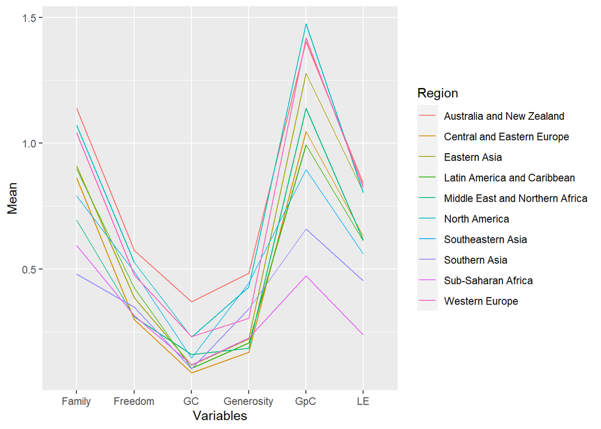

```r
#Graficamos el dataframe largo
ggplot(df_mean_region_long, aes(x = factor(variable), y = value, group=Region, color=Region)) +
  geom_line() +
  labs(x = "Variables", y = "Mean") +
  scale_x_discrete(labels = c("Family", "Freedom", "GC", "Generosity", "GpC", "LE"))
```

# 2. Intervalo de confianza de la esperanza de vida (LE)

Calculad el intervalo de confianza de la variable LE (Life Expectancy) al 95%. Dibujad también un gráfico que muestre la distribución de la variable LE. En ambos casos, considerad todos los países de la muestra.

Interpretad el resultado.

**Nota 1**: No podéis usar funciones que calculen el intervalo de confianza. Sí podéis usar funciones como qt, qnorm, pt, pnorm. **Nota 2**: Implementad una función que calcule el intervalo de confianza. Así podréis reutilizarla en el apartado siguiente sin tener que implementarla de nuevo.

```r
IC <- function(var, confidenceLevel) {
  sd <- sd(var)
  n <- length(var)
  SE <- sd / sqrt(n)
  t <- qt(confidenceLevel, n-1)
  L <- mean(var) - t*SE
  U <- mean(var) + t*SE
  round(c(L,U), 2)
}

IC_LE_95 = IC(happiness$LE, 0.95)
IC_LE_95
```

```
## [1] 0.53 0.59
```

```r
#Convertimos la variable en texto para utilizarla despues en el informe
IC_LE_95_text = as.character(IC_LE_95)
```

Dado que la desviación típica es desconocida, solo tenemos la desviación típica muestral que es una estimación de la poblacional. Así calculamos el error estándar (SE). Debido a que estamos estimando la desviación estándar añadimos errores al cálculo, por esta razón empleamos otra distribución que la desviación normal estándar, la distribución t student. Sin embargo, cuando tenemos los grados de libertad mayores a 30, la distribución t student es casi idéntica a la distribución normal estándar. En nuestro caso, los grados de libertad son 156, por lo que los valores del intervalo de confianza utiliazando la distribución t student son similares si hubieramos utilizado la distribución normal estándar.

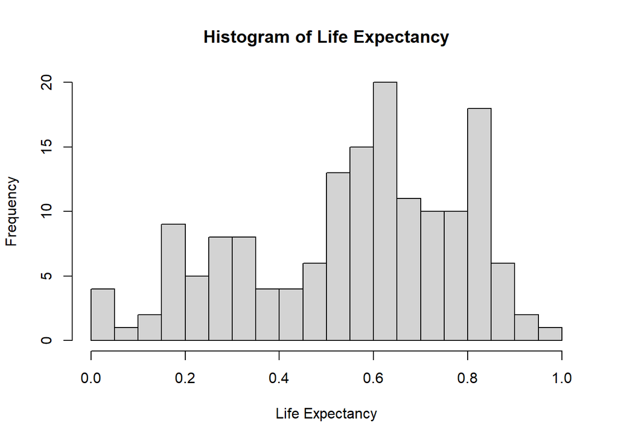

```r
#Graficamos la distribución de la variable de Life Expentancy (LE)
hist(happiness$LE, breaks=20, main="Histogram of Life Expectancy", xlab="Life Expectancy")
```

# 3. Intervalo de confianza de LE de dos regiones

Nos preguntamos si LE es significativamente diferente entre África y Europa. Para ello, calculad los intervalos de confianza al 95% entre estas dos “macro-regiones” o continentes. Debéis agrupar todas las regiones de África en una única macro-región “Africa” y realizar lo mismo con las distintas regiones de Europa. La unidad de observación de cada muestra sigue siendo el país. Luego comparad e interpretad los intervalos de confianza de las macro-regiones/continentes. Acompañad el análisis de un gráfico ilustrativo.

En el caso que las diferencias observadas sean significativas al 95%, calculad los intervalos de confianza al 98%. Interpretad los resultados.

**Nota**: usad la función desarrollada en el apartado anterior.

```r
#AFRICA

Africa_LE <- happiness[happiness$Region %in% c("Sub-Saharan Africa", "Middle East and Northern Africa"), c("LE")]

print(paste("El tamaño de la muestra de la esperanza de vida en Africa es:", length(Africa_LE)))
```

```
## [1] "El tamaño de la muestra de la esperanza de vida en Africa es: 57"
```

```r
#EUROPA

Europe_LE <- happiness[happiness$Region %in% c("Central and Eastern Europe", "Western Europe"), c("LE")]

print(paste("El tamaño de la muestra de la esperanza de vida en Africa es:", length(Europe_LE)))
```

```
## [1] "El tamaño de la muestra de la esperanza de vida en Africa es: 50"
```

```r
#Intervalos de confianza de Africa y Europa al 95%
IC_Africa_LE_95 = IC(Africa_LE, 0.95)
IC_Africa_LE_95
```

```
## [1] 0.32 0.41
```

```r
IC_Europe_LE_95 = IC(Europe_LE, 0.95)
IC_Europe_LE_95
```

```
## [1] 0.69 0.74
```

Como podemos ver los intervalos de confianza de la esperanza de vida de los dos continentes no se superponen al 95%, esto significa que existe una diferencia estadísticamente significativa entre las esperanzas de vida de los dos continentes. Obervamos que Europa tiene una expectativa de vida mas alta.

```r
#Intervalos de confianza de Africa y Europa al 98%
IC_Africa_LE_98 = IC(Africa_LE, 0.98)
IC_Africa_LE_98
```

```
## [1] 0.31 0.43
```

```r
IC_Europe_LE_98 = IC(Europe_LE, 0.98)
IC_Europe_LE_98
```

```
## [1] 0.68 0.75
```

Los intervalos de confianza de la esperanza de vida siguen sin suponerse al 98%, por lo que la conclusión anterior se mantiene.

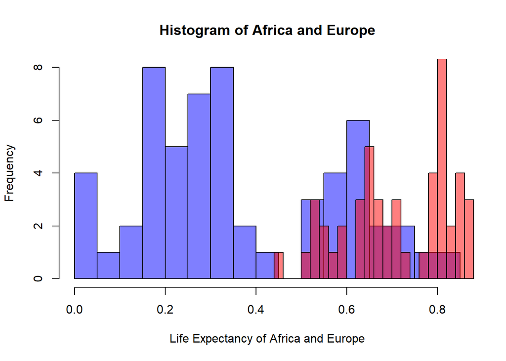

```r
#Graficación de la variable LE para Africa y Europa
hAfrica_LE <- hist(Africa_LE, plot=FALSE, breaks=20)
hEurope_LE <- hist(Europe_LE, plot=FALSE, breaks=20)

plot(hAfrica_LE, col = rgb(0, 0, 1, alpha = 0.5), main="Histogram of Africa and Europe", xlab="Life Expectancy of Africa and Europe")
plot(hEurope_LE, col = rgb(1, 0, 0, alpha = 0.5), add = TRUE)
```

Los dos histogramas de Europa Y Africa se solapan, lo que indica que los valores de las distribuciones de los dos continentes se solapan.

Es importante tener en cuenta que la significancia estadística y la significancia práctica no son lo mismo. La significancia estadística simplemente significa que es poco probable que una diferencia entre las dos variables haya ocurrido por casualidad. El significado práctico, por otro lado, se refiere a la importancia o relevancia en el mundo real de la diferencia o relación.

En este caso, es posible que la diferencia en la esperanza de vida entre los dos continentes sea estadísticamente significativa, pero el alcance de la diferencia puede no ser significativo en la práctica. La superposición de los histogramas podría indicar que la diferencia en la esperanza de vida es relativamente pequeña o que existe una variación importante dentro de cada continente.

# 4. Contraste de hipótesis sobre la esperanza de vida

Seguimos estudiando la esperanza de vida entre los continentes de África y Europa. Realizad un contraste de hipótesis para comprobar si la esperanza de vida en Europa es significativamente mayor que en África al 98% de confianza.

## 4.1 Hipótesis nula y alternativa

Ho = meanA - meanE = 0; Ha = meanA - meanE < 0

## 4.2 Tipo de contraste

Es un contraste para la media de dos muestras unilateral paramétrico. Debido a que los tamaños de las muestras son mayores a 30, podemos aplicar el Teorema del Límite Central la cual nos indica que la distribución de la media muestral se comporta como una distribución normal estándar cuando es suficientemente grande (n>30). Por lo tanto, es Contraste Paramétrico. Es claramente para dos muestras porque tenemos dos continentes: África y Europa. Es Contraste de Media porque no se establece de otra manera. Y es unilateral, porque el enunciado nos indica que la hipótesis alternativa sería la esperanza de vida en Europa es mayor que en Africa.

## 4.3 Cálculos

Implementad los cálculos necesarios para realizar el contraste, siguiendo el proceso indicado en el apartado anterior. Calculad el valor observado, el valor crítico y el valor p.

**Nota**: No podéis usar funciones que calculen el contraste. Sí podéis usar funciones como qt, qnorm, pt, pnorm.

```r
#Calculamos las varianzas
var(Africa_LE)
```

```
## [1] 0.04673522
```

```r
var(Europe_LE)
```

```
## [1] 0.01344784
```

```r
var.test(Africa_LE, Europe_LE)
```

```
##
##  F test to compare two variances
##
## data:  Africa_LE and Europe_LE
## F = 3.4753, num df = 56, denom df = 49, p-value = 1.8e-05
## alternative hypothesis: true ratio of variances is not equal to 1
## 95 percent confidence interval:
##  1.998574 5.982295
## sample estimates:
## ratio of variances
##           3.475297
```

La hipótesis nula del F-test es que las varianzas de las dos muestras son iguales. Si el valor p es menor que el nivel de significación elegido (normalmente 0,05), rechazamos la hipótesis nula y concluimos que las varianzas no son iguales. Si el valor p es mayor que el nivel de significación, entonces no podemos rechazar la hipótesis nula y concluir que las varianzas son similares.

Por lo tanto, rechazamos la hipótesis nula y concluimos que las varianzas de las muestras de la esperanza de vida de África y Europa no son similares. Así, podemos utilizar la estadística pertinente.

```r
# Medias de las muestras de Africa y Europa
meanA = mean(Africa_LE)
meanE = mean(Europe_LE)

#Varianzas de las muestras
varA = var(Africa_LE)
varE = var(Europe_LE)

# Tamaño de las muestras
nA = length(Africa_LE)
nE = length(Europe_LE)


# t-score/Valor Observado
t = (meanA -meanE)/(sqrt((varA/nA) + (varE/nE)))
print(paste("Valor Observado/t-score: ", t))
```

```
## [1] "Valor Observado/t-score:  -10.5383659863152"
```

```r
# Grados de libertad
df = (((varA/nA)+(varE/nE))**2)/ (((1/(nA-1))*((varA/nA)**2)) + ((1/(nE-1))*((varE/nE)**2)))
print(paste("Degrees of freedom: ", df))
```

```
## [1] "Degrees of freedom:  87.9494856893774"
```

```r
#Valor Crítico. Contraste unilateral de 98%
valorCriticoAE = qt(0.02, df)
print(paste("Valor Critico: ", valorCriticoAE))
```

```
## [1] "Valor Critico:  -2.08465609198108"
```

```r
#Valor p
valor_p_AE = pt(t, df)
print(paste("Valor p: ", valor_p_AE))
```

```
## [1] "Valor p:  1.43061825732194e-17"
```

```r
# t-test en dos muestras
test <- t.test(Africa_LE, Europe_LE, alternative="less", var.equal=FALSE)
test$p.value
```

```
## [1] 1.430618e-17
```

```r
test
```

```
##
##  Welch Two Sample t-test
##
## data:  Africa_LE and Europe_LE
## t = -10.538, df = 87.949, p-value < 2.2e-16
## alternative hypothesis: true difference in means is less than 0
## 95 percent confidence interval:
##       -Inf -0.292891
## sample estimates:
## mean of x mean of y
## 0.3653942 0.7131400
```

## 4.4 Interpretación

En función de los resultados obtenidos en el apartado anterior, concluid si podemos aceptar o rechazar las hipótesis planteadas y dad respuesta a la pregunta de investigación.

Podemos ver que el *Valor Observado* -10.54 es extremadamente menor que el *Valor Critico* -2.08. La región de aceptación está comprendida [-2.09, infinito), por lo tanto, nos encontramos fuera de la zona de aceptación de la hipótesis nula.

De igual manera el *Valor p* es muy menor al 0.02 (2%) de *nivel de significancia*. Por lo tanto, rechazamos la hipótesis nula. Entonces, se concluye que la esperanza de vida en África es menor que la esperanza de vida en Europa.

# 5 Contraste de hipótesis en relación a la familia

Nos preguntamos ahora si existen diferencias significativas en el valor de Family entre las regiones Southern Asia y Western Europe con un nivel de confianza del 95%.

```r
# Obtenemos los valores de la variable Family de la Region de Southern Asia

SA_Family <- happiness[happiness$Region %in% c("Southern Asia"), c("Family")]

print(paste("El tamaño de la muestra de la Familia en Southern Asia es: ", length(SA_Family)))
```

```
## [1] "El tamaño de la muestra de la Familia en Southern Asia es:  7"
```

```r
# Obtenemos los valores de la variable Family de la Region de Western Europe

WE_Family <- happiness[happiness$Region %in% c("Western Europe"), c("Family")]

print(paste("El tamaño de la muestra de la Familia en Western Europe es: ", length(WE_Family)))
```

```
## [1] "El tamaño de la muestra de la Familia en Western Europe es:  21"
```

[figure not shown]

```r
#Graficación de la variable LE para Africa y Europa
hist(SA_Family, col = rgb(0, 0, 1, alpha = 0.5), main="Histogram of Southern Asia and Western Europe", xlab="Life Expectancy of Southern Asia and Western Europe")
hist(WE_Family, col = rgb(1, 0, 0, alpha = 0.5), add = TRUE )
```

## 5.1 Hipótesis nula y alternativa

Ho = meanSA - meanWE = 0; Ha = meanSA - meanWE no es igual a 0

## 5.2 Tipo de contraste

Especificad qué tipo de contraste aplicaréis y su justificación.

El enunciado menciona que queremos sabes si entre las dos muestras existen “diferencias significativas”. Como no se indica una dirección clara, entonces asumimos que la hipótesis alternativa sería bilateral.

De manera similar, se asume que utilizamos las medias.

Por lo tanto, el tipo de contraste que usamos es para dos muestras sobre las medias no paramétrico y bilateral.

## 5.3 Aplicación del test

Aplicad el test para realizar el contraste de hipótesis, según la justificación proporcionada en el apartado anterior. Podéis usar cualquier función de R que resuelva este contraste. No es necesario desarrollar el código.

Para el test utilizaríamos la función de R wilcox.test().

```r
wilcox.test(SA_Family, WE_Family)
```

```
##
##  Wilcoxon rank sum exact test
##
## data:  SA_Family and WE_Family
## W = 6, p-value = 5.067e-05
## alternative hypothesis: true location shift is not equal to 0
```

El valor p es 0.00005067.

## 5.4 Interpretación

En función de los resultados obtenidos en el apartado anterior, concluid si podemos aceptar o rechazar las hipótesis planteadas y dad respuesta a la pregunta de investigación.

Dado que el *Valor p* es muy menor al 0.025 (2.5%) resultado de la mitad del *nivel de significancia* 0.05 (lo dividimos porque es bilateral). Por lo tanto, rechazamos la hipótesis nula. Entonces, se concluye que en efecto existe una diferencia significativa entre el valor de Family de las regiones Southern Asia y Western Europe.

## 5.5 Cálculos

Explicad brevemente cómo se realiza el cómputo del test que habéis aplicado. No es necesario implementar el código.

Lo que realiza el test Wilcoxon es:

1. Une los datos de las dos muestras y ordena las observaciones de menor a mayor. Si dos o más observaciones son iguales, les asigna el promedio de los rangos que habrían recibido.
2. Calcula la suma de los rangos para cada muestra.
3. Calcula la estadística de prueba usando la muestra menor entre la suma de los rangos de una muestra y la suma de los rangos de la otra muestra.

# 6 Contraste de hipótesis sobre la felicidad

Nos interesa estudiar ahora la felicidad en algunas regiones. Concretamente, nos interesa comparar los países de Asia con los países de África. La pregunta que nos hacemos es si la proporción de países con un valor de felicidad (HS) inferior a 6 es menor en los países de Asia en comparación con los países de África. Para ello, debéis calcular la proporción de países que tiene un valor HS inferior a 6 en cada continente por separado.

Luego, determinad si existen diferencias significativas, según la pregunta planteada, con un nivel de confianza del 95%. Seguid los pasos que se indican a continuación.

```r
# Obtenemos los valores de la variable Happiness Score (HS) que sean menores a 6 de la Region de Asia

Asia_HS <- happiness[happiness$Region %in% c("Eastern Asia", "Southern Asia", "Southeastern Asia"), c("HS")]

print(paste("El tamaño de la muestra de la HS en Asia es: ", length(Asia_HS)))
```

```
## [1] "El tamaño de la muestra de la HS en Asia es:  22"
```

```r
Asia_HS_6 <- happiness[happiness$Region %in% c("Eastern Asia", "Southern Asia", "Southeastern Asia") & happiness$HS < 6, c("HS")]

print(paste("El tamaño de la muestra de la HS menores a 6 en Asia es: ", length(Asia_HS_6)))
```

```
## [1] "El tamaño de la muestra de la HS menores a 6 en Asia es:  18"
```

```r
# Obtenemos los valores de la variable Happiness Score (HS) que sean menores a 6 de la Region de Asia

Africa_HS <- happiness[happiness$Region %in% c("Middle East and Northern Africa", "Sub-Saharan Africa"), c("HS")]

print(paste("El tamaño de la muestra de la HS en Africa es: ", length(Africa_HS)))
```

```
## [1] "El tamaño de la muestra de la HS en Africa es:  57"
```

```r
Africa_HS_6 <- happiness[happiness$Region %in% c("Middle East and Northern Africa", "Sub-Saharan Africa") & happiness$HS < 6, c("HS")]

print(paste("El tamaño de la muestra de la HS menores a 6 en Africa es: ", length(Africa_HS_6)))
```

```
## [1] "El tamaño de la muestra de la HS menores a 6 en Africa es:  50"
```

## 6.1 Hipótesis nula y alternativa

Ho = pAsia - pAfrica = 0 ; Ha = pAsia - pAfrica < 0

## 6.2 Test

Indicad qué tipo de test aplicaréis y su justificación.

Es un contraste de hipótesis de dos muestras, porque comparamos muestras de Asia y Africa. Además, explicitamente la métrica es proporción como menciona el enunciado. Además, es unilateral porque el enunciado indica una dirección en donde la proporción “es menor en los países de Asia en comparación con los países de África”. Por lo tanto, el tipo de contraste de hipótesis es de dos muestras unilateral sobre la proporción.

Dado que el tamaño de la muestra de Africa es grande (>30), entonces tiene una distribución aproximadamente normal. Se puede deducir que la variable aleatoria sigue una distribución normal estándar. Por lo tanto utilizamos el valor z.

## 6.3 Cálculo de las proporciones

Calculad la proporción de países que tiene un valor HS inferior a 6 en cada continente por separado.

```r
# Proporcion de Asia
pAsia = length(Asia_HS_6)/length(Asia_HS)
pAsia
```

```
## [1] 0.8181818
```

```r
# Proporcion de Africa
pAfrica = length(Africa_HS_6)/length(Africa_HS)
pAfrica
```

```
## [1] 0.877193
```

## 6.4 Desarrollo del contraste

Implementad un código que calcule este contraste. Mostrad los resultados del test: valor observado, valor p, valor crítico.

**Nota**: No podéis usar funciones ya implementadas en R que devuelvan el resultado de este contraste. Sí podéis usar qnorm, qt, etcétera.

```r
# Contar el número de éxitos y fracasos en cada muestra
nAsia <- length(Asia_HS)
nAfrica <- length(Africa_HS)

successesAsia <- length(Asia_HS_6)
successesAfrica <- length(Africa_HS_6)

failuresAsia <- nAsia - successesAsia
failuresAfrica <- nAfrica - successesAfrica



# Valor Observado HS
common_p = (successesAsia + successesAfrica)/ (nAsia + nAfrica)
valorObservado_HS = (pAsia-pAfrica)/(sqrt(common_p*(1-common_p)*(1/nAsia+1/nAfrica)))
print(paste("Valor Observado: ", valorObservado_HS))
```

```
## [1] "Valor Observado:  -0.679118714023954"
```

```r
#Valor Crítico. Contraste unilateral de 95%
valorCritico_HS = qnorm(0.05)
print(paste("Valor Critico: ", valorCritico_HS))
```

```
## [1] "Valor Critico:  -1.64485362695147"
```

```r
# Valor p
p_value_HS = pnorm(valorObservado_HS)
print(paste("Valor p: ", p_value_HS))
```

```
## [1] "Valor p:  0.248531322925274"
```

```r
prop.test(x = c(successesAsia, successesAfrica), n = c(nAsia, nAfrica), alternative = "less", correct=FALSE)
```

```
##
##  2-sample test for equality of proportions without continuity correction
##
## data:  c(successesAsia, successesAfrica) out of c(nAsia, nAfrica)
## X-squared = 0.4612, df = 1, p-value = 0.2485
## alternative hypothesis: less
## 95 percent confidence interval:
##  -1.00000000  0.09398457
## sample estimates:
##    prop 1    prop 2
## 0.8181818 0.8771930
```

## 6.5 Interpretación del test

Interpretad el resultado del contraste y responded a la pregunta planteada.

Podemos ver que el *Valor Observado* -0.679 es mayor que el *Valor Critico* -1.645. La región de aceptación está comprendida [-1.645, infinito), por lo tanto, nos encontramos dentro de la zona de aceptación de la hipótesis nula.

De igual manera el *Valor p* 0.249 es mayor al 0.05 (5%) de *nivel de significancia*. Por lo tanto, no rechazamos la hipótesis nula. Entonces, se concluye que la proporción de países con un valor de felicidad (HS) inferior a 6 no es menor en los países de Asia en comparación con los países de África.

# 7 Tabla resumen

Presentad una tabla con los resultados principales de cada sección: la pregunta de investigación planteada, los valores obtenidos y la conclusión obtenida en cada apartado. La tabla puede tener un formato como el que se muestra a continuación. Esta tabla nos ayuda a tener una visión general y técnica de los resultados del estudio.

[output not shown]

# 8 Resumen ejecutivo

Resumid las conclusiones del estudio para una audiencia no técnica, indicando las respuestas a las preguntas de investigación planteadas. El resumen no debe ocupar más de media página.

**Nota**: esta pregunta trabaja la competencia de comunicación que es muy importante en el rol de analista de datos.

[output not shown]